# Лабораторная работа №4

Александр Эдуардович Аскеров

Российский университет дружбы народов

2025-10-25

# Информация

## Докладчик

- Аскеров Александр Эдуардович
- Кафедра теории вероятностей и кибербезопасности
- Российский университет дружбы народов им. П. Лумумбы

# Вводная часть

## Цель работы

Основной целью работы является изучение возможностей специализированных пакетов Julia для выполнения и оценки эффективности операций над объектами линейной алгебры.

## Задание

1. Используя Jupyter Lab, повторите примеры из раздела 4.2.
2. Выполните задания для самостоятельной работы.

# Поэлементные операции над многомерными массивами

Повторим примеры из раздела поэлементные операции над многомерными массивами.

Для матрицы $4 \times 3$ рассмотрим поэлементные операции сложения и произведения её элементов:

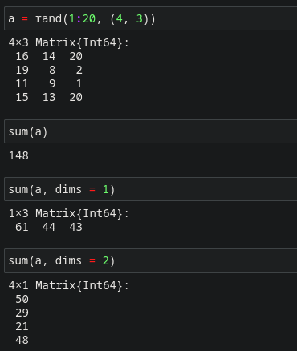

Рисунок 1: Поэлементные операции над многомерными массивами 1

# Поэлементные операции над многомерными массивами

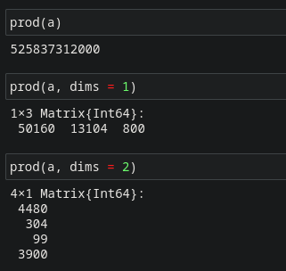

Рисунок 2: Поэлементные операции над многомерными массивами 2

# Поэлементные операции над многомерными массивами

Для работы со средними значениями можно воспользоваться возможностями пакета Statistics:

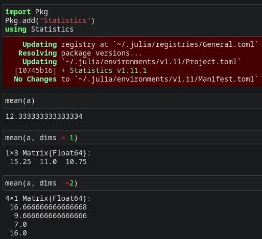

Рисунок 3: Поэлементные операции над многомерными массивами 3

# Транспонирование, след, ранг, определитель и инверсия матрицы

Повторим примеры из раздела транспонирование, след, ранг, определитель и инверсия матрицы.

Для выполнения таких операций над матрицами, как транспонирование, диагонализация, определение следа, ранга, определителя матрицы и т.п. можно воспользоваться библиотекой (пакетом) LinearAlgebra:

# Транспонирование, след, ранг, определитель и инверсия матрицы

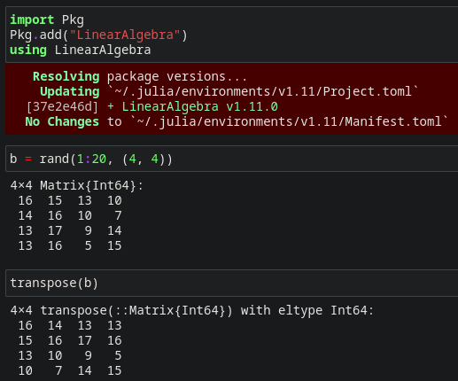

Рисунок 4: Транспонирование, след, ранг, определитель и инверсия матрицы 1

# Транспонирование, след, ранг, определитель и инверсия матрицы

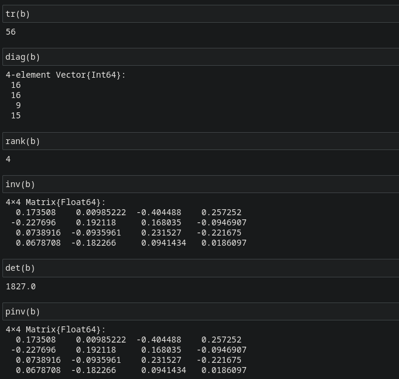

Рисунок 5: Транспонирование, след, ранг, определитель и инверсия матрицы 2

# Вычисление нормы векторов и матриц, повороты, вращения

Повторим примеры из раздела вычисление нормы векторов и матриц, повороты, вращения.

Для вычисления нормы используется LinearAlgebra.norm(x).

Евклидова норма:

$$\| \vec{X} \|_2 = \sqrt{x_1^2 + x_2^2 + \dots + x_n^2}$$

p-норма:

$$\| \vec{A} \|_p = \left( \sum_{i=1}^n |a_i|^p \right)^{1/p}$$

# Вычисление нормы векторов и матриц, повороты, вращения

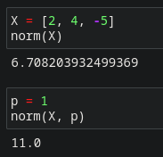

Рисунок 6: Вычисление нормы векторов и матриц, повороты, вращения 1

# Вычисление нормы векторов и матриц, повороты, вращения

Евклидово расстояние между двумя векторами $\vec{X}$ и $\vec{Y}$ определяется как $\| \vec{X} - \vec{Y} \|_2$.

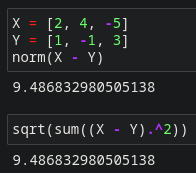

Рисунок 7: Вычисление нормы векторов и матриц, повороты, вращения 2

# Вычисление нормы векторов и матриц, повороты, вращения

Угол между двумя векторами $\vec{X}$ и $\vec{Y}$ определяется как $\cos^{-1}\left( \frac{\vec{X}^T \vec{Y}}{\| \vec{X} \|_2 \| \vec{Y} \|_2} \right)$.

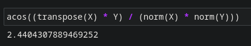

Рисунок 8: Вычисление нормы векторов и матриц, повороты, вращения 3

# Вычисление нормы векторов и матриц, повороты, вращения

Вычисление нормы для двумерной матрицы:

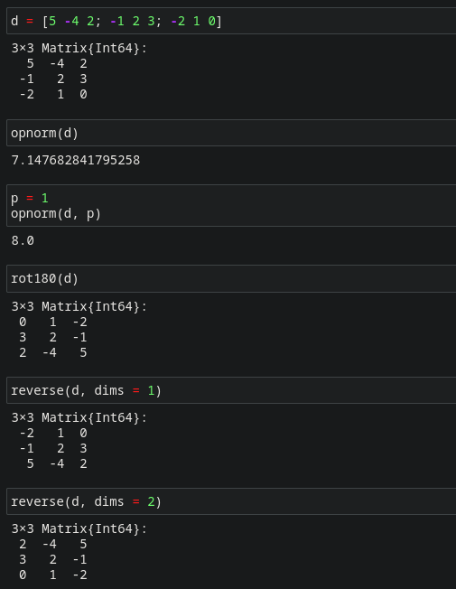

Рисунок 9: Вычисление нормы векторов и матриц, повороты, вращения 4

# Матричное умножение, единичная матрица, скалярное произведение

Повторим примеры из раздела матричное умножение, единичная матрица, скалярное произведение.

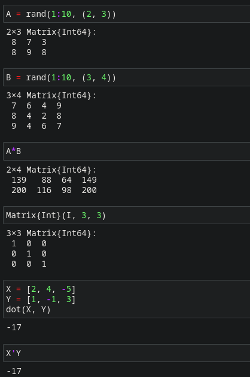

Рисунок 10: Матричное умножение, единичная матрица, скалярное произведение

# Факторизация, специальные матричные структуры

Повторим примеры из раздела факторизация, специальные матричные структуры. Решение систем линейный алгебраических уравнений $Ax = b$:

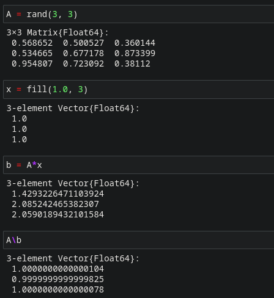

Рисунок 11: Факторизация, специальные матричные структуры 1

# Факторизация, специальные матричные структуры

Julia позволяет вычислять LU-факторизацию и определяет составной тип факторизации для его хранения:

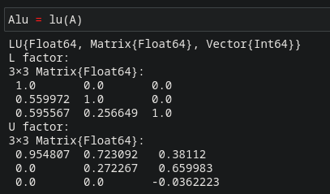

Рисунок 12: Факторизация, специальные матричные структуры 2

# Факторизация, специальные матричные структуры

Различные части факторизации могут быть извлечены путём доступа к их специальным свойствам:

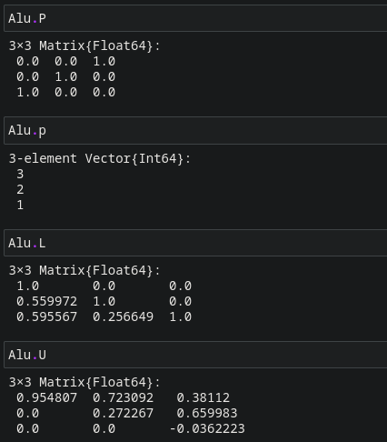

Рисунок 13: Факторизация, специальные матричные структуры 3

# Факторизация, специальные матричные структуры

Исходная система уравнений $Ax = b$ может быть решена или с использованием исходной матрицы, или с использованием объекта факторизации:

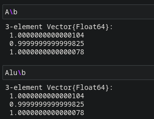

Рисунок 14: Факторизация, специальные матричные структуры 4

# Факторизация, специальные матричные структуры

Аналогично можно найти детерминант матрицы:

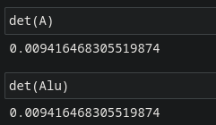

Рисунок 15: Факторизация, специальные матричные структуры 5

# Факторизация, специальные матричные структуры

Julia позволяет вычислять QR-факторизацию и определяет составной тип факторизации для его хранения:

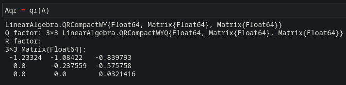

Рисунок 16: Факторизация, специальные матричные структуры 6

# Факторизация, специальные матричные структуры

По аналогии с LU-факторизацией различные части QR-факторизации могут быть извлечены путём доступа к их специальным свойствам:

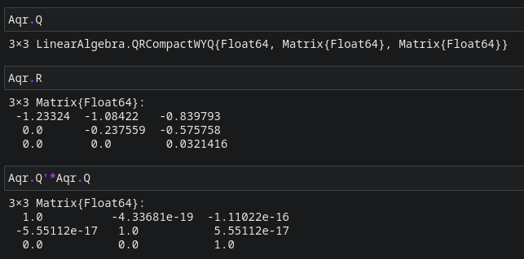

Рисунок 17: Факторизация, специальные матричные структуры 7

# Факторизация, специальные матричные структуры

Примеры собственной декомпозиции матрицы $A$:

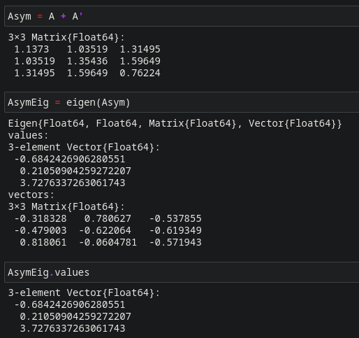

Рисунок 18: Факторизация, специальные матричные структуры 8

# Факторизация, специальные матричные структуры

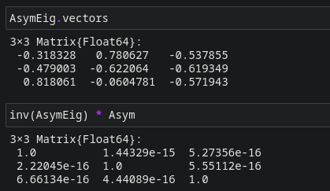

Рисунок 19: Факторизация, специальные матричные структуры 9

# Факторизация, специальные матричные структуры

Далее рассмотрим примеры работы с матрицами большой размерности и специальной структуры.

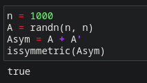

Рисунок 20: Факторизация, специальные матричные структуры 10

# Факторизация, специальные матричные структуры

# Факторизация, специальные матричные структуры

В Julia можно объявить структуру матрицы явно, например, используя Diagonal,Triangular, Symmetric, Hermitian, Tridiagonal и SymTridiagonal:

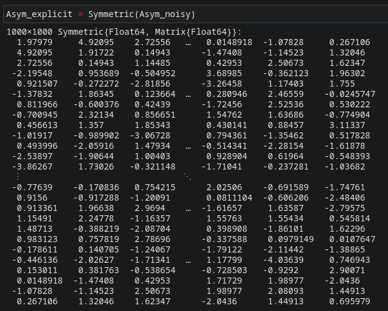

Рисунок 22: Факторизация, специальные матричные структуры 12

# Факторизация, специальные матричные структуры

Далее для оценки эффективности выполнения операций над матрицами большой размерности и специальной структуры воспользуемся пакетом BenchmarkTools:

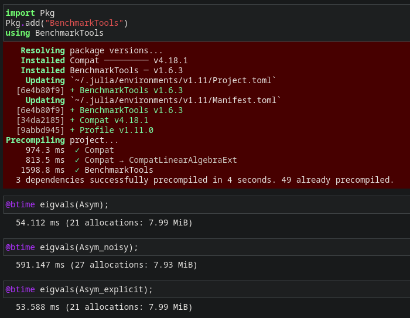

Рисунок 23: Факторизация, специальные матричные структуры 13

# Факторизация, специальные матричные структуры

Далее рассмотрим примеры работы с разряженными матрицами большой размерности.

Использование типов Tridiagonal и SymTridiagonal для хранения трёхдиагональных матриц позволяет работать с потенциально очень большими трёхдиагональными матрицами:

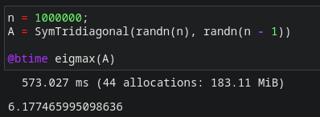

Рисунок 24: Факторизация, специальные матричные структуры 14

# Факторизация, специальные матричные структуры

# Общая линейная алгебра

Повторим примеры из раздела общая линейная алгебра.

Julia также поддерживает общую линейную алгебру, что позволяет, например, работать с матрицами и векторами рациональных чисел.

# Общая линейная алгебра

В следующем примере показано, как можно решить систему линейных уравнений с рациональными элементами без преобразования в типы элементов с плавающей запятой (для избежания проблемы с переполнением используем BigInt):

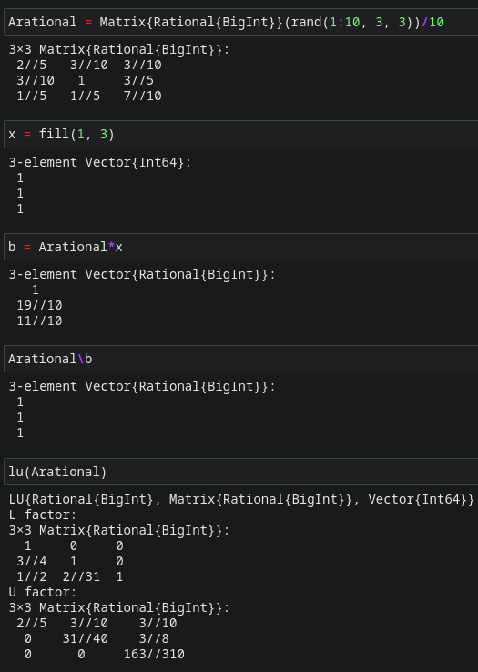

Рисунок 27: Общая линейная алгебра 2

# Выполнение заданий для самостоятельной работы

# Произведение векторов

2.Умножьте v матрично на себя (внешнее произведение), присвоив результат переменной outer_v.

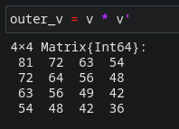

Рисунок 29: Задание 2